# Marketing Campaigns Project

## Problem scenario:

Marketing mix stands as a widely utilized concept in the execution of marketing strategies. It encompasses various facets within a comprehensive marketing plan, with a central focus on the four Ps of marketing: product, price, place, and promotion.

## Problem objective:

As a data scientist, you must conduct exploratory data analysis and hypothesis testing to enhance your comprehension of the diverse factors influencing customer acquisition.

## Data description:

The variables such as birth year, education, income, and others pertain to the first 'P' or 'People' in the tabular data presented to the user. The expenditures on items like wine, fruits, and gold, are associated with ‘Product’. Information relevant to sales channels, such as websites and stores, is connected to ‘Place’, and the fields discussing promotions and the outcomes of various campaigns are linked to ‘Promotion’.

## Steps to perform:

#### 1. After importing the data, examine variables such as Dt_Customer and Income to verify their accurate importation.

```python
import pandas as pd
df=pd.read_csv("marketing_data.csv",parse_dates=True)
df
```

|  | ID | Year_Birth | Education | Marital_Status | Income | Kidhome | Teenhome | Dt_Customer | Recency | MntWines | ... | NumStorePurchases | NumWebVisitsMonth | AcceptedCmp3 | AcceptedCmp4 | AcceptedCmp5 | AcceptedCmp1 | AcceptedCmp2 | Response | Complain | Country |
| --- | --- | --- | --- | --- | --- | --- | --- | --- | --- | --- | --- | --- | --- | --- | --- | --- | --- | --- | --- | --- | --- |
| 0 | 1826 | 1970 | Graduation | Divorced | $84,835.00 | 0 | 0 | 6/16/14 | 0 | 189 | ... | 6 | 1 | 0 | 0 | 0 | 0 | 0 | 1 | 0 | SP |
| 1 | 1 | 1961 | Graduation | Single | $57,091.00 | 0 | 0 | 6/15/14 | 0 | 464 | ... | 7 | 5 | 0 | 0 | 0 | 0 | 1 | 1 | 0 | CA |
| 2 | 10476 | 1958 | Graduation | Married | $67,267.00 | 0 | 1 | 5/13/14 | 0 | 134 | ... | 5 | 2 | 0 | 0 | 0 | 0 | 0 | 0 | 0 | US |
| 3 | 1386 | 1967 | Graduation | Together | $32,474.00 | 1 | 1 | 5/11/14 | 0 | 10 | ... | 2 | 7 | 0 | 0 | 0 | 0 | 0 | 0 | 0 | AUS |
| 4 | 5371 | 1989 | Graduation | Single | $21,474.00 | 1 | 0 | 4/8/14 | 0 | 6 | ... | 2 | 7 | 1 | 0 | 0 | 0 | 0 | 1 | 0 | SP |
| ... | ... | ... | ... | ... | ... | ... | ... | ... | ... | ... | ... | ... | ... | ... | ... | ... | ... | ... | ... | ... | ... |
| 2235 | 10142 | 1976 | PhD | Divorced | $66,476.00 | 0 | 1 | 3/7/13 | 99 | 372 | ... | 11 | 4 | 0 | 0 | 0 | 0 | 0 | 0 | 0 | US |
| 2236 | 5263 | 1977 | 2n Cycle | Married | $31,056.00 | 1 | 0 | 1/22/13 | 99 | 5 | ... | 3 | 8 | 0 | 0 | 0 | 0 | 0 | 0 | 0 | SP |
| 2237 | 22 | 1976 | Graduation | Divorced | $46,310.00 | 1 | 0 | 12/3/12 | 99 | 185 | ... | 5 | 8 | 0 | 0 | 0 | 0 | 0 | 0 | 0 | SP |
| 2238 | 528 | 1978 | Graduation | Married | $65,819.00 | 0 | 0 | 11/29/12 | 99 | 267 | ... | 10 | 3 | 0 | 0 | 0 | 0 | 0 | 0 | 0 | IND |
| 2239 | 4070 | 1969 | PhD | Married | $94,871.00 | 0 | 2 | 9/1/12 | 99 | 169 | ... | 4 | 7 | 0 | 1 | 1 | 0 | 0 | 1 | 0 | CA |

2240 rows × 28 columns

```python
import pandas as pd
# Read the CSV and parse the date column
df = pd.read_csv("marketing_data.csv", parse_dates=True)
# Print the Dt_Customer column
print(df['Dt_Customer'])
```

```
0        6/16/14
1        6/15/14
2        5/13/14
3        5/11/14
4         4/8/14
          ...
2235      3/7/13
2236     1/22/13
2237     12/3/12
2238    11/29/12
2239      9/1/12
Name: Dt_Customer, Length: 2240, dtype: object
```

```python
df.columns = df.columns.str.replace(r'\s+', '', regex=True)  # Remove all spaces
df.columns
```

```
Index(['ID', 'Year_Birth', 'Education', 'Marital_Status', 'Income', 'Kidhome',
       'Teenhome', 'Dt_Customer', 'Recency', 'MntWines', 'MntFruits',
       'MntMeatProducts', 'MntFishProducts', 'MntSweetProducts',
       'MntGoldProds', 'NumDealsPurchases', 'NumWebPurchases',
       'NumCatalogPurchases', 'NumStorePurchases', 'NumWebVisitsMonth',
       'AcceptedCmp3', 'AcceptedCmp4', 'AcceptedCmp5', 'AcceptedCmp1',
       'AcceptedCmp2', 'Response', 'Complain', 'Country'],
      dtype='object')
```

```python
# Convert "Income" to numeric after removing $ and commas (if needed)
df["Income"] = df["Income"].replace({'\$': '', ',': ''}, regex=True).astype(float)
# Print the cleaned Income column
print(df['Income'])
```

```
0       84835.0
1       57091.0
2       67267.0
3       32474.0
4       21474.0
         ...
2235    66476.0
2236    31056.0
2237    46310.0
2238    65819.0
2239    94871.0
Name: Income, Length: 2240, dtype: float64
```

```python
# Check unique values in "Education" and "Marital_Status"
education_unique = df["Education"].unique()
marital_status_unique = df["Marital_Status"].unique()
print(education_unique, marital_status_unique, df["Income"].isnull().sum())

#Standardize the category names of Education and Marital Status
# Standardize marital status categories
df["Marital_Status"] = df["Marital_Status"].replace({
    "YOLO": "Single",
    "Alone": "Single",
    "Absurd": "Single"  # Assuming these are unconventional ways of indicating being single
})

# Verify cleaned categories
print(df["Marital_Status"].unique())

# Compute mean income for each (Education, Marital_Status) group
income_means = df.groupby(["Education", "Marital_Status"])["Income"].mean()

# Impute missing income values based on the group mean
df["Income"] = df.apply(
    lambda row: income_means[row["Education"], row["Marital_Status"]] if pd.isnull(row["Income"]) else row["Income"],
    axis=1
)
print(income_means)
# Verify if all missing values are filled
df["Income"].isnull().sum()
```

```
['Graduation' 'PhD' '2n Cycle' 'Master' 'Basic'] ['Divorced' 'Single' 'Married' 'Together' 'Widow'] 0
['Divorced' 'Single' 'Married' 'Together' 'Widow']
Education   Marital_Status
2n Cycle    Divorced          49395.130435
            Married           46201.100000
            Single            53673.944444
            Together          44736.410714
            Widow             51392.200000
Basic       Divorced           9548.000000
            Married           21960.500000
            Single            18238.666667
            Together          21240.071429
            Widow             22123.000000
Graduation  Divorced          54526.042017
            Married           50800.258741
            Single            51365.633065
            Together          55758.480702
            Widow             54976.657143
Master      Divorced          50331.945946
            Married           53286.028986
            Single            53787.142857
            Together          52109.009804
            Widow             58401.545455
PhD         Divorced          53096.615385
            Married           58138.031579
            Single            53039.666667
            Together          56041.422414
            Widow             60288.083333
Name: Income, dtype: float64
```

```
0
```

#### 3. Create variables to represent the total number of children, age, and total spending.

```python
from datetime import datetime

# Create 'Total_Children' as the sum of 'Kidhome' and 'Teenhome'
df["Total_Children"] = df["Kidhome"] + df["Teenhome"]

# Create 'Age' based on 'Year_Birth'
current_year = datetime.now().year
df["Age"] = current_year - df["Year_Birth"]

# Create 'Total_Spending' as the sum of all monetary spending columns
spending_columns = df.loc[:,"MntWines" : "MntGoldProds"]
df["Total_Spending"] = spending_columns.sum(axis=1)

# Display the first few rows to verify
df[["Total_Children", "Age", "Total_Spending"]]
```

|  | Total_Children | Age | Total_Spending |
| --- | --- | --- | --- |
| 0 | 0 | 55 | 1190 |
| 1 | 0 | 64 | 577 |
| 2 | 1 | 67 | 251 |
| 3 | 2 | 58 | 11 |
| 4 | 1 | 36 | 91 |
| ... | ... | ... | ... |
| 2235 | 1 | 49 | 689 |
| 2236 | 1 | 48 | 55 |
| 2237 | 1 | 49 | 309 |
| 2238 | 0 | 47 | 1383 |
| 2239 | 2 | 56 | 1078 |

2240 rows × 3 columns

#### 4. Derive the total purchases from the number of transactions across the three channels.

```python
# Total Purchases across Three channels (NumWebPurchases,NumStorePurchases,NumCatalogPurchases)
spending_columns = df.loc[:,"NumWebPurchases" : "NumStorePurchases"]
df["Total_Purchases"] = spending_columns.sum(axis=1)
df["Total_Purchases"]
```

```
0       14
1       17
2       10
3        3
4        6
        ..
2235    18
2236     4
2237    12
2238    19
2239    17
Name: Total_Purchases, Length: 2240, dtype: int64
```

#### 5. Generate box plots and histograms to gain insights into identify outliers. Implement outlier treatment as needed

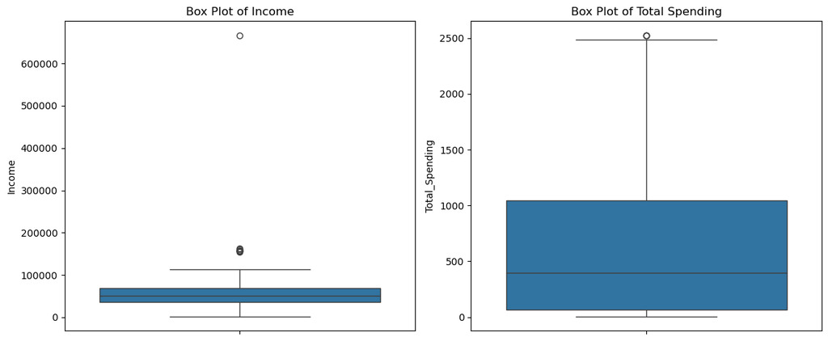

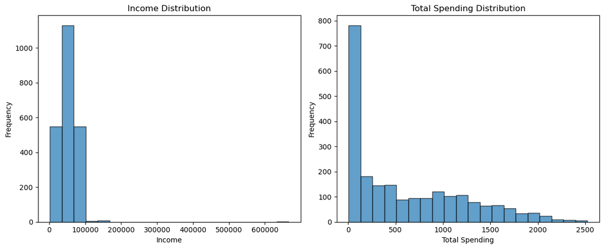

```
((2240, 33), (2229, 33))
```

```python
import matplotlib.pyplot as plt
import seaborn as sns
import numpy as np

# Create 'Total_Spending' as the sum of all monetary spending columns
spending_columns = ["MntWines", "MntFruits", "MntMeatProducts", "MntFishProducts", "MntSweetProducts", "MntGoldProds"]
df["Total_Spending"] = df[spending_columns].sum(axis=1)

# ---- Step 1: Generate Box Plots ----
plt.figure(figsize=(12, 5))

# Box plot for Income
plt.subplot(1, 2, 1)
sns.boxplot(y=df["Income"])
plt.title("Box Plot of Income")

# Box plot for Total Spending
plt.subplot(1, 2, 2)
sns.boxplot(y=df["Total_Spending"])
plt.title("Box Plot of Total Spending")

plt.tight_layout()
plt.show()

# ---- Step 2: Generate Histograms ----
plt.figure(figsize=(12, 5))

# Histogram for Income
plt.subplot(1, 2, 1)
plt.hist(df["Income"], bins=20, edgecolor="black", alpha=0.7)
plt.xlabel("Income")
plt.ylabel("Frequency")
plt.title("Income Distribution")

# Histogram for Total Spending
plt.subplot(1, 2, 2)
plt.hist(df["Total_Spending"], bins=20, edgecolor="black", alpha=0.7)
plt.xlabel("Total Spending")
plt.ylabel("Frequency")
plt.title("Total Spending Distribution")

plt.tight_layout()
plt.show()

# ---- Step 3: Outlier Detection & Treatment (IQR Method) ----
def remove_outliers(df, column):
    Q1 = df[column].quantile(0.25)
    Q3 = df[column].quantile(0.75)
    IQR = Q3 - Q1
    lower_bound = Q1 - 1.5 * IQR
    upper_bound = Q3 + 1.5 * IQR
    return df[(df[column] >= lower_bound) & (df[column] <= upper_bound)]

# Remove outliers from Income and Total Spending
df_cleaned = remove_outliers(df, "Income")
df_cleaned = remove_outliers(df_cleaned, "Total_Spending")

# Display the number of rows before and after outlier removal
df.shape, df_cleaned.shape
```